# Main Analysis

Felix Heim, Jana Schneider, Jana, Leon

December 5, 2020

## Claim 1 - Search Data Cases

## Claim 2 - Strict lockdown measures have prevented a thorough spread in South Korea

**Our initial motivation:**

- After a massive increase in daily cases, it appears that the government of South Korea was able to reduce the number of daily cases remarkably within a few days and continued to retain a constant low level.

**Claim description in more detail:**

- Stricter lockdown measures lead to a lower outbreak of the Covid-19 Virus
- Compared to other countries, for example Germany, the government of South Korea reacted more effectively and efficiently

**Our approach:**

- We first compared the daily cases of South Korea with the ones of Germany.
- Next we looked at the different types of government policy’ measures.
- Within each type of policy we analysed the different measures in terms of time to daily cases.

[figure not shown]

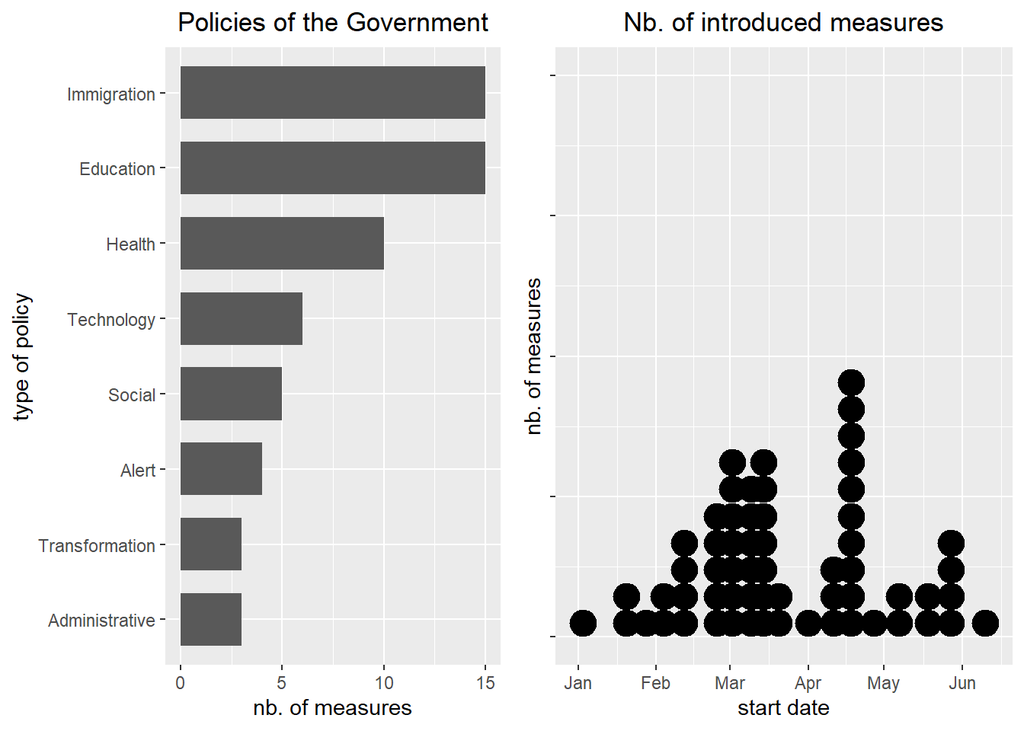

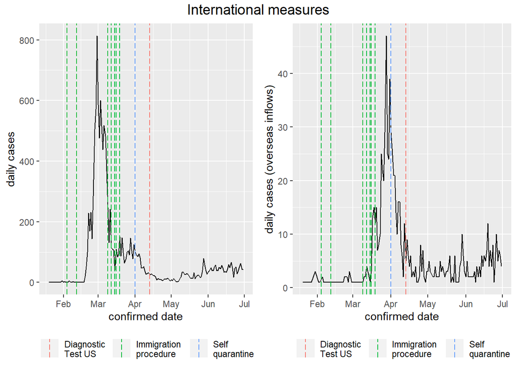

###### Short Analysis

- After the number of daily cases related to overseas inflow reached a very high level, the government of South Korea imposed a mandatory 14-day Self-Quarantine. It seems that after a short time the number of daily cases related to overseas inflow could be reduced sharply and retained a relatively stable level.
- After experiencing a peak in numbers, the government of South Korea establisehd special immigration procedures for foreign countries in order to prevent another severe increase in numbers caused by people entering the country. However, one can note that shortly afterwards the number of daily cases related to overseas inflow first increased before plunging afterwards.

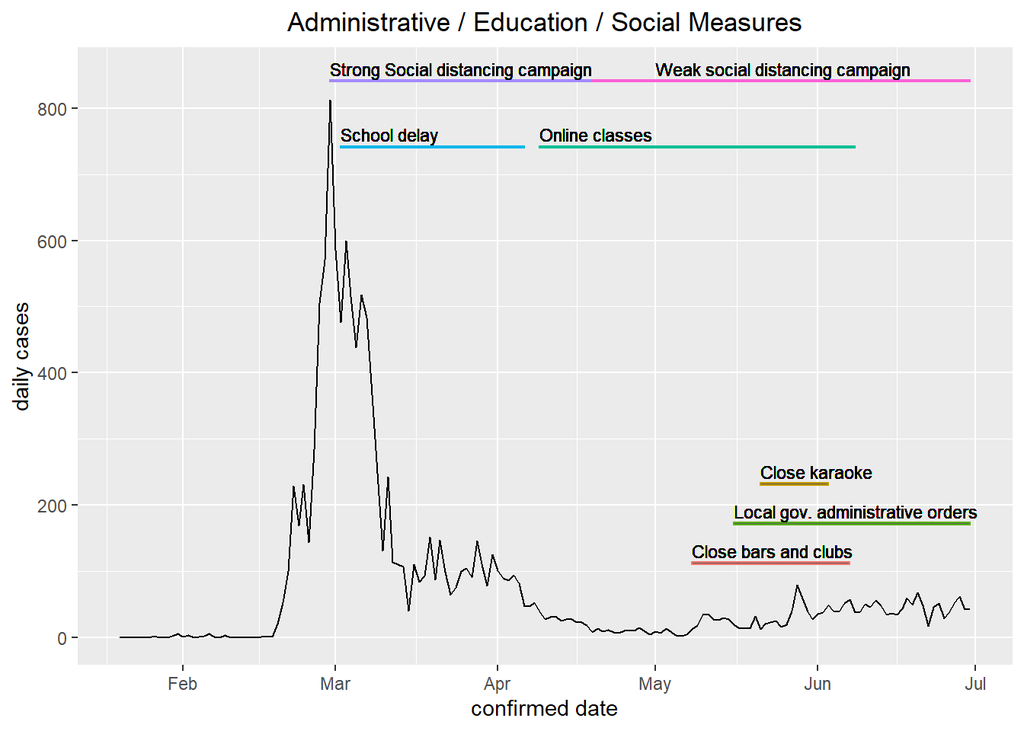

###### Short Analysis

- After the number of daily cases have reached peak in March, numerous meausures with the aim of social distancing, such as delaying school start, were introduced. It seems that through these measures the number of daily cases could be reduced.
- In the begining of May, after the number of daily cases tended to increase again, further public indoor gathering places were forced closed. It seems that through that another severe outbreak was prevented.

## Claim 3 - Region and Superspreaders